# NFL 2020 Week 11

MAJ Daniel Baller

8/27/2019

## Instructor Group Predictions

This Week's Predictions

Week 11

| Game | Prediction | Winner | Correct | Correct Votes | Correct Percent |
| --- | --- | --- | --- | --- | --- |
| 1 | Seattle Seahawks | Seattle Seahawks | Yes | 12 | 0.6667 |
| 2 | New England Patriots | Houston Texans | No | 2 | 0.1111 |
| 3 | Detroit Lions | Carolina Panthers | No | 4 | 0.2222 |
| 4 | Cleveland Browns | Cleveland Browns | Yes | 18 | 1.0000 |
| 5 | Pittsburgh Steelers | Pittsburgh Steelers | Yes | 17 | 0.9444 |
| 6 | Baltimore Ravens | Tennessee Titans | No | 7 | 0.3889 |
| 7 | Tie | Washington Football Team | -- | 9 | 0.5000 |
| 8 | New Orleans Saints | New Orleans Saints | Yes | 15 | 0.8333 |
| 9 | Los Angeles Chargers | Los Angeles Chargers | Yes | 17 | 0.9444 |
| 10 | Miami Dolphins | Denver Broncos | No | 0 | 0.0000 |
| 11 | Minnesota Vikings | Dallas Cowboys | No | 0 | 0.0000 |
| 12 | Green Bay Packers | Indianapolis Colts | No | 8 | 0.4444 |
| 13 | Kansas City Chiefs | Kansas City Chiefs | Yes | 18 | 1.0000 |
| 14 | Tampa Bay Buccaneers | Los Angeles Rams | No | 1 | 0.0556 |

Our win percentage for the week is 0.4615

Our season win percentage so far is 0.6352

Games picked this season 159

Correct Games this season 101

predictions this week

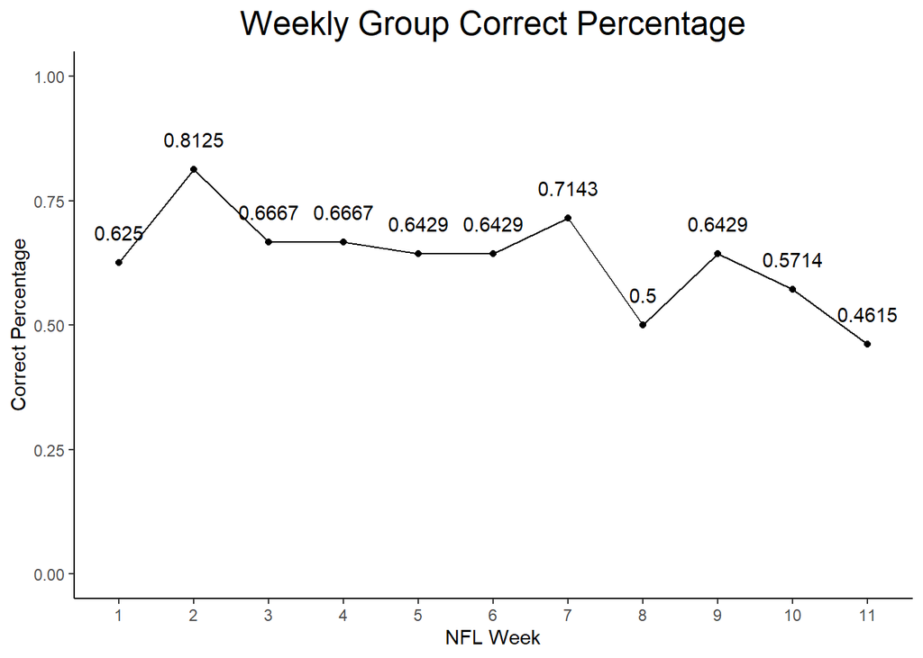

## Individual Predictions

Individual Results

Week 11

Name

Weekly # Correct

Percent

Weeks Picked

Season Percent

Adj Season Percent

Season Trend

Week 1

Week 2

Week 3

Week 4

Week 5

Week 6

Week 7

Week 8

Week 9

Week 10

Week 11

Gabriel Costa

9

12

6

9

10

7

9

7

10

10

9

0.6923

11

0.6164

0.6164

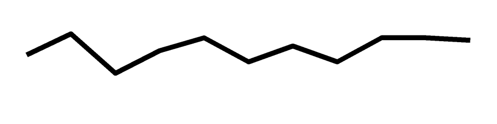

Frank Czerniakowski

7

13

10

9

8

6

9

6

11

5

9

0.6923

11

0.5849

0.5849

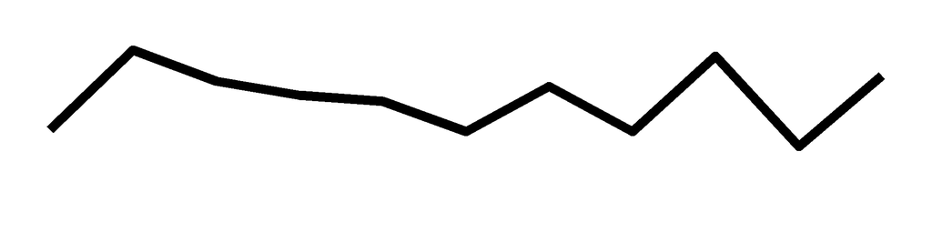

Kevin Quigley

8

8

9

10

10

8

8

6

8

7

9

0.6923

11

0.5723

0.5723

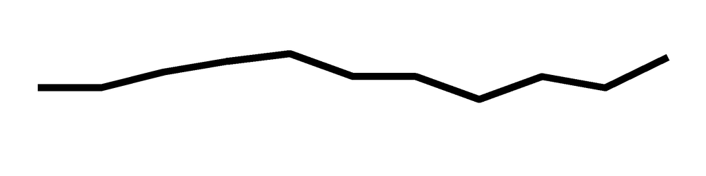

Daniel Baller

11

10

10

9

9

5

8

9

11

10

8

0.6154

11

0.6289

0.6289

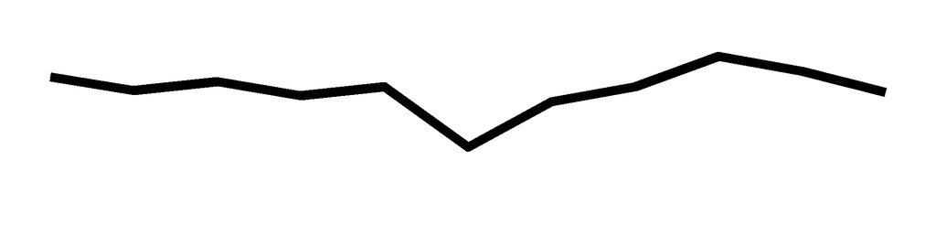

Eric Swenson

4

8

10

9

9

8

9

8

7

8

8

0.6154

11

0.5535

0.5535

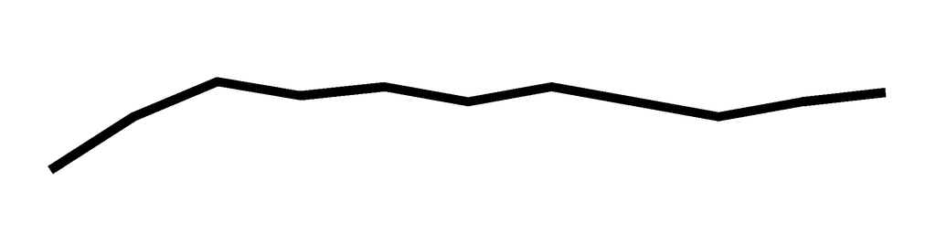

Shane Clark

10

14

9

9

9

9

10

NA

11

7

7

0.5385

10

0.6552

0.5956

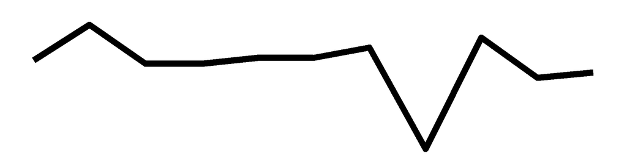

Gregory Minetos

9

14

10

12

8

8

12

7

10

7

7

0.5385

11

0.6541

0.6541

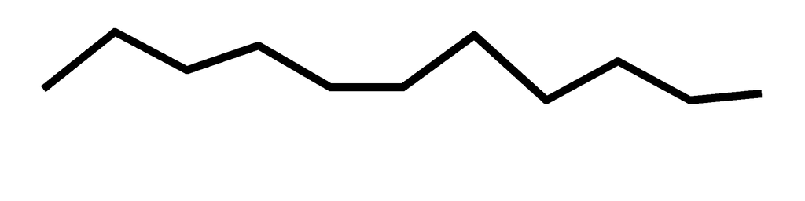

James Pleuss

9

12

10

12

7

8

10

9

9

10

7

0.5385

11

0.6478

0.6478

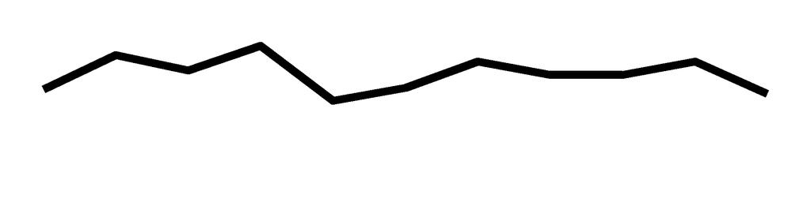

Margaret Wieczorek

11

14

9

9

8

NA

10

8

9

8

7

0.5385

10

0.6414

0.5831

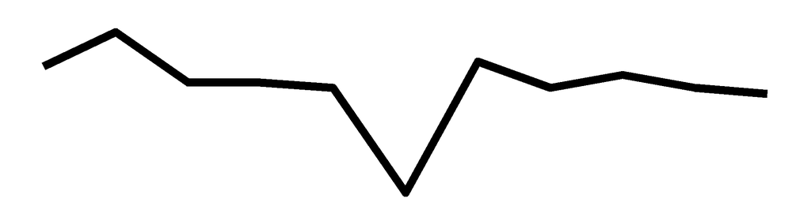

Travis Russell

11

8

8

11

10

10

10

8

NA

NA

7

0.5385

9

0.6336

0.5184

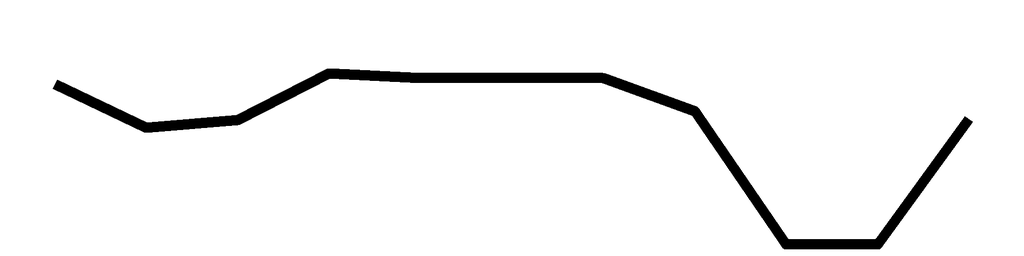

Michael Prokos

9

12

9

8

11

10

9

7

9

9

7

0.5385

11

0.6289

0.6289

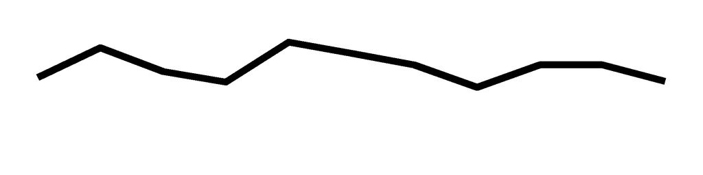

Kevin Cummiskey

13

11

9

9

10

7

9

5

10

9

7

0.5385

11

0.6226

0.6226

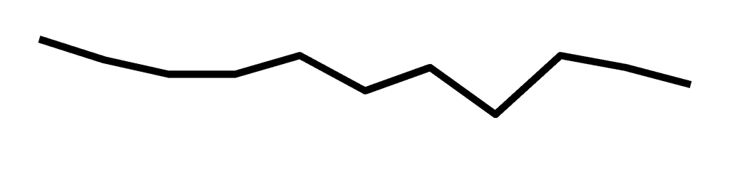

Blake Schwartz

10

9

10

10

10

9

9

6

5

8

7

0.5385

11

0.5849

0.5849

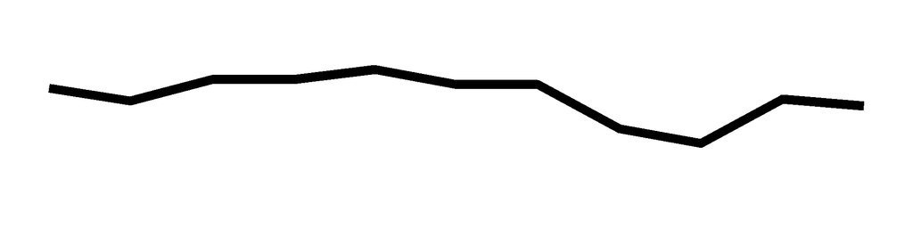

James Starling

15

12

9

12

10

NA

11

8

10

10

6

0.4615

10

0.7103

0.6457

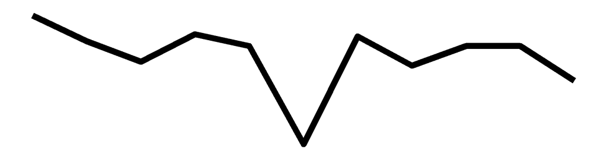

John Kearby

9

11

6

9

9

8

12

6

9

10

6

0.4615

11

0.5975

0.5975

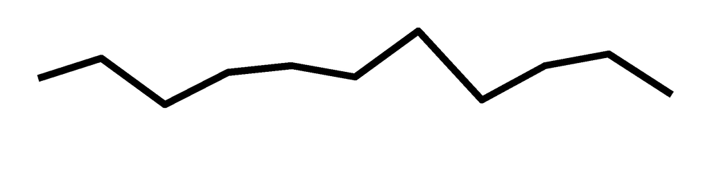

Nicholas Reisweber

9

10

10

8

10

7

8

8

10

9

6

0.4615

11

0.5975

0.5975

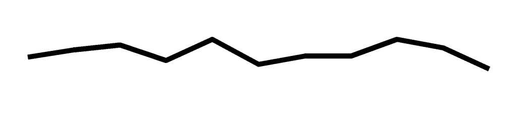

Tina Hartley

9

11

10

8

8

9

9

7

3

8

6

0.4615

11

0.5535

0.5535

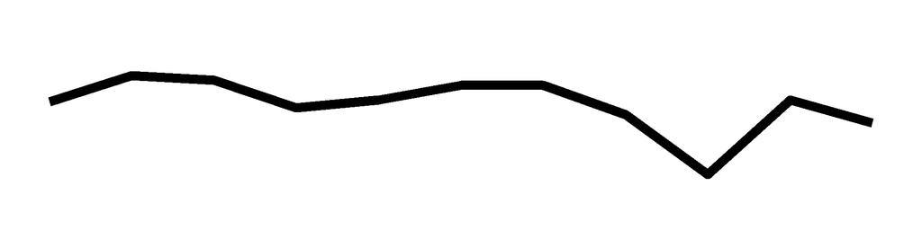

Welvin Lucero

9

11

9

10

NA

NA

11

8

NA

8

5

0.3846

8

0.6068

0.4413

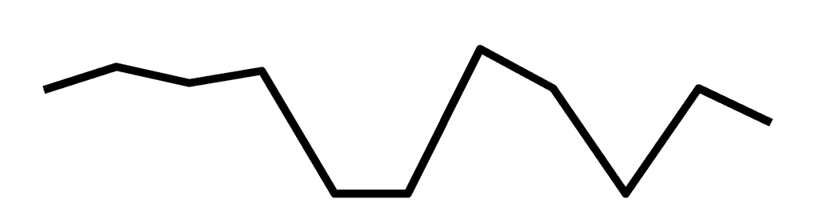

Daniel Richardson

13

11

10

10

8

NA

8

NA

NA

NA

NA

0.0000

6

0.6667

0.3637

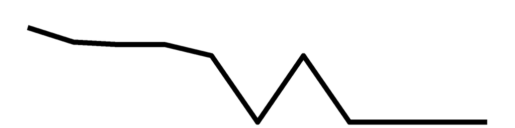

Josephine Cammack

9

11

12

10

9

9

11

7

6

8

NA

0.0000

10

0.6301

0.5728

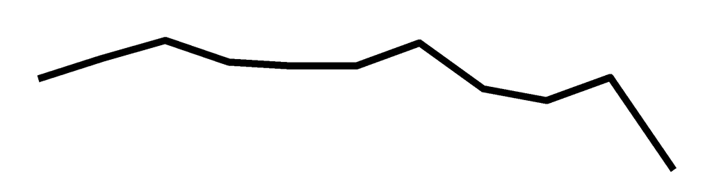

Andrew Lee

9

10

8

NA

NA

NA

NA

NA

NA

NA

NA

0.0000

3

0.5745

0.1567

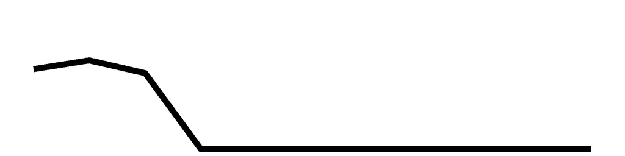

Timothy Moore

10

11

8

9

7

9

7

7

7

NA

NA

0.0000

9

0.5682

0.4649

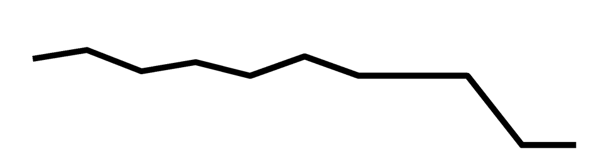

Congrats Gabriel Costa for having the best picks this week, with a correct percentage of 0.6923, Congrats Frank Czerniakowski for having the best picks this week, with a correct percentage of 0.6923, Congrats Kevin Quigley for having the best picks this week, with a correct percentage of 0.6923

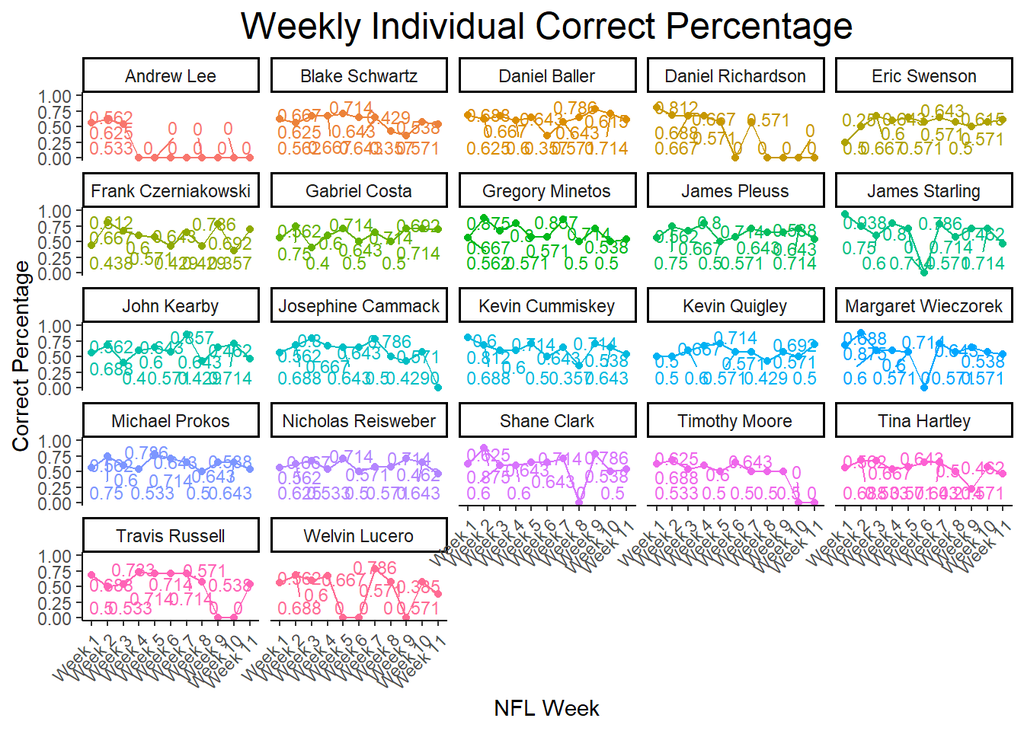

## MA206 Group Predictions

This Week's MA206 Predictions

Week 11

| Game | Prediction | Winner | Correct | Correct Votes | Correct Percent |
| --- | --- | --- | --- | --- | --- |
| 1 | Seattle Seahawks | Seattle Seahawks | Yes | 7 | 0.5833 |
| 2 | New England Patriots | Houston Texans | No | 1 | 0.0833 |
| 3 | Detroit Lions | Carolina Panthers | No | 3 | 0.2500 |
| 4 | Cleveland Browns | Cleveland Browns | Yes | 11 | 0.9167 |
| 5 | Pittsburgh Steelers | Pittsburgh Steelers | Yes | 12 | 1.0000 |
| 6 | Tie | Tennessee Titans | -- | 6 | 0.5000 |
| 7 | Cincinnati Bengals | Washington Football Team | No | 3 | 0.2500 |
| 8 | New Orleans Saints | New Orleans Saints | Yes | 8 | 0.6667 |
| 9 | Los Angeles Chargers | Los Angeles Chargers | Yes | 11 | 0.9167 |
| 10 | Miami Dolphins | Denver Broncos | No | 0 | 0.0000 |
| 11 | Minnesota Vikings | Dallas Cowboys | No | 1 | 0.0833 |
| 12 | Green Bay Packers | Indianapolis Colts | No | 4 | 0.3333 |
| 13 | Kansas City Chiefs | Kansas City Chiefs | Yes | 11 | 0.9167 |
| 14 | Tampa Bay Buccaneers | Los Angeles Rams | No | 3 | 0.2500 |

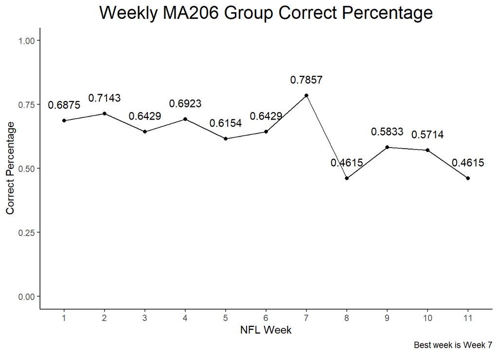